# Data Visualization DSCI-D590 Module 3 assignment

Name: Anitha Ganapathy  
Email: aganapa@iu.edu

Assignment link: https://github.com/yy/dviz-course/blob/master/m03-integrity/lab.md  
Fix it or break it!  
In this assignment, you choose to be either a good 😇 or a bad 😈 person. Follow the instruction below and submit your paper to Canvas.  
😇  
Find a highly misleading visualization (you can have more than one!). Write a short paper (also feel free to publish in your blog or something) that

- dissects and explains why the visualizations are misleading.
- explains how can the visualization be fixed.
- provides a fixed visualization (either hand-drawn or plotted with any tool)

😈  
Find a perfectly fine visualization (you can have more than one!). Write a short paper that

- how can those visualization can be manipulated to mislead one way or the other
- provides a manipulated version of the visualization (either hand-drawn or plotted with any tool) - the more malicious and subtle it is, the better!  
  NOTE: For assignment, You are required to write a paper on one of the above two (good or bad) and not both but if you are interested, you can write for both.

# **I choose 😈**

## For my paper I choose to be the 😈 to find a perfectly fine visualization and write a short paper about the same

**Reference**

- https://blog.quantinsti.com/stock-market-data-analysis-python/

```python
!pip install yfinance
```

```python
import datetime
import numpy as np
import pandas as pd
import matplotlib.pyplot as plt
from matplotlib.dates import DateFormatter
from pandas.plotting import scatter_matrix
%matplotlib inline
```

```python
# Import yfinance package
import yfinance as yf

# Set the start and end date
start_date = '1990-01-01'
end_date = '2022-05-20'

# Set the ticker
ticker = 'AMZN'
ticker_2 = 'GOOGL'
# Get the data
data = yf.download(ticker, start_date, end_date)
data_G = yf.download(ticker_2, start_date, end_date)
```

```
[*********************100%***********************]  1 of 1 completed
[*********************100%***********************]  1 of 1 completed
```

```python
start_date = '2012-11-1'
end_date = '2020-12-31'
data = data[data.index > start_date ]
data_G = data_G[data_G.index > start_date ]
```

## Perfect representation of data with context and labels for Amazon and Google stock prices.

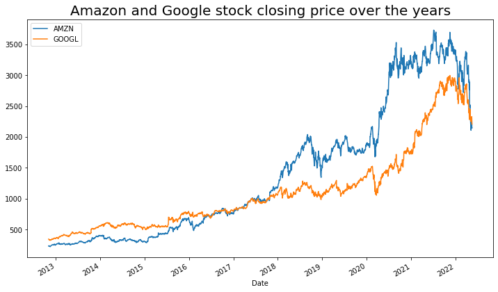

```python
# Plot adjusted close price data
fig , ax = plt.subplots(figsize=(12,7))
ax = data['Close'].plot(label = "AMZN")
ax = data_G['Close'].plot(label = "GOOGL")
plt.legend()
plt.title("Amazon and Google stock closing price over the years", fontsize = 20)
plt.show()
```

## Misrepresenting the data by not providing the title and the axis labels.

I have even omitted to provide the context by forgetting to mention that its for the Amazon and Google stock price beginning the year 2020 which is the start of Covid pandemic.

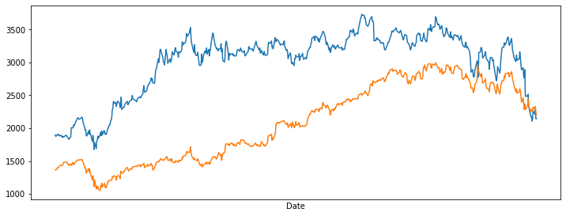

```python
fig , ax = plt.subplots(figsize=(12,5))
ax = data[data.index > '2020-01-01']['Close'].plot()
ax = data_G[data_G.index > '2020-01-01']['Close'].plot()
plt.tick_params(
    axis='x',          # changes apply to the x-axis
    which='both',      # both major and minor ticks are affected
    bottom=False,      # ticks along the bottom edge are off
    top=False,         # ticks along the top edge are off
    labelbottom=False) # labels along the bottom edge are off
plt.show()
```

## Stock price fluctions and not mentioning the period for which it is represented

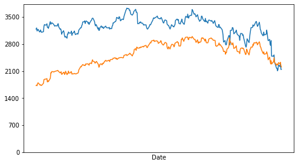

```python
fig , ax = plt.subplots(figsize=(8,5))
ax = data[data.index > '2021-01-01']['Close'].plot()
ax = data_G[data_G.index > '2021-01-01']['Close'].plot()
plt.tick_params(
    axis='x',          # changes apply to the x-axis
    which='both',      # both major and minor ticks are affected
    bottom=False,      # ticks along the bottom edge are off
    top=False,         # ticks along the top edge are off
    labelbottom=False) # labels along the bottom edge are off
# Setting the interval of ticks of y-axis to 10.
listOf_Yticks = np.arange(0, 3800, 700)
plt.yticks(listOf_Yticks)
plt.show()
```

## Ways to mislead or misrepresent.

- Not providing the context
- Not displaying the axis ticks or simly put what the x and y axis labels are
- Deleteing few records in the data
- Not choosing the right scaling factor for the plots
- to represent the data with out of context correlations.

## Convert the notebook to HTML

```python
# %%shell
# jupyter nbconvert --to html /content/Modile03 assign_Ganapathy_Anitha.ipynb
```